# Inferential statistics

## Hypothesis testing

## About hypothesis testing

- Hypothesis testing is a process for which **after assuming a certain hypothesis** we associate our sample to the realization of a certain random variable.
  - Step 1. **Collect** a sample \(X\).
  - Step 2. **Set a hypothesis** \(H_0\) about the distribution generating \(X\).
  - Step 3. **Compute a test statistics from sample** \(X\), for which we know its distribution.
  - Step 4. **Calculate the probability**, \(p\), to obtain test statistics associated to samples that are less likely to hold hypothesis \(H_0\). The probability \(p\) is called \(p\)-value.
  - Step 5. **Decide** about the credibility of \(H_0\) using probability \(p\).

## Hypothesis testing for the mean

- Step 1. Collect a sample

```r
X_num = c(10.2, 8.8, 11.2, 9, 9.6, 10.3, 10.2, 13.2, 12.5, 7)
```

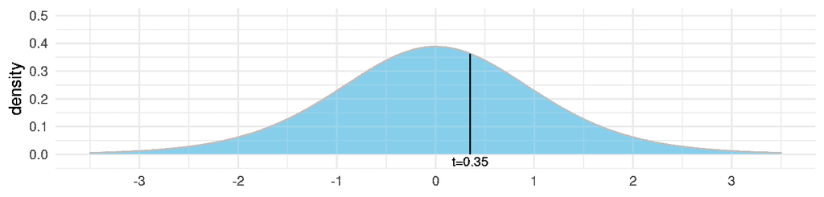

- Step 5. Is it rare an event that rarer events happen with probability 0.7344?

## Hypothesis testing for the mean

- Step 1. Collect a sample

```r
X_num = c(10.2, 8.8, 11.2, 9, 9.6, 10.3, 10.2, 13.2, 12.5, 7)
```

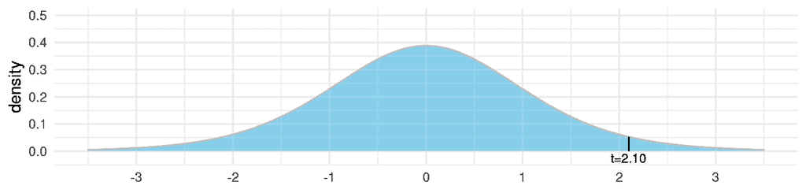

## Hypothesis testing for proportions

- Step 1. Given a dichotomous sample \(X=\{x_1, \dots, x_{20}\}\):

```r
X_bin = c(0, 0, 0, 0, 0, 1, 0, 0, 0, 0, 0, 0, 1, 0, 0, 0, 1, 0, 1, 0)
```

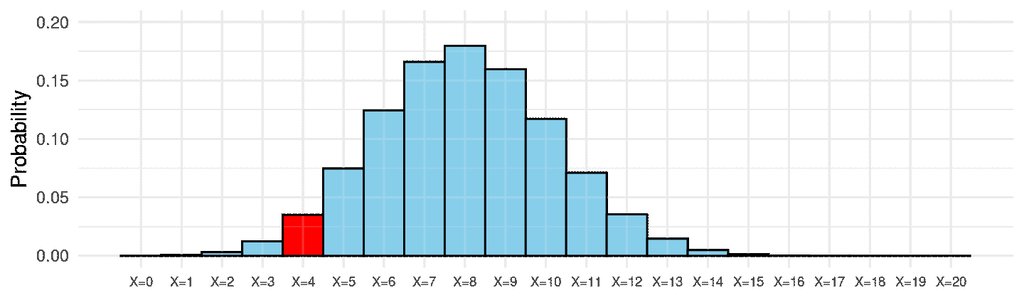

- Step 5. Is it rare an event that rarer events happen with probability 0.072?

## One sample t-test with R

- \(H_0: \mu = 10\)

```r
t.test(X_num, mu = 10)
```

```
#>
#>  One Sample t-test
#>
#> data:  X_num
#> t = 0.35052, df = 9, p-value = 0.734
#> alternative hypothesis: true mean is not equal to 10
#> 95 percent confidence interval:
#>   8.90927 11.49073
#> sample estimates:
#> mean of x
#>      10.2
```

## One sample t-test with R

- \(H_0: \mu = 9\)

```r
t.test(X_num, mu = 9)
```

```
#>
#>  One Sample t-test
#>
#> data:  X_num
#> t = 2.1031, df = 9, p-value = 0.06479
#> alternative hypothesis: true mean is not equal to 9
#> 95 percent confidence interval:
#>   8.90927 11.49073
#> sample estimates:
#> mean of x
#>      10.2
```

## Exact binomial test with R

- \(H_0: \pi = 0.4\)

```r
binom.test(sum(X_bin), n = length(X_bin), p = 0.4)
```

```
#>
#>  Exact binomial test
#>
#> data:  sum(X_bin) and length(X_bin)
#> number of successes = 4, number of trials = 20, p-value = 0.07198
#> alternative hypothesis: true probability of success is not equal to 0.4
#> 95 percent confidence interval:
#>  0.057334 0.436614
#> sample estimates:
#> probability of success
#>                    0.2
```

## Comparing group means (1)

- Step 1.

```r
data = tibble(
  X = c(80.8, 78.2, 81, 79.9, 80.7, 79.3, 78.7, 79.6, 79.5, 79.3,  # <- A
        81.8, 81.4, 78.3, 79.4, 82.1, 81.3, 79, 80.5, 81.1, 80.2), # <- B
  G = c(rep('A', 10), rep('B', 10))
)
```

- Step 2. \(H_0: \mu_A = \mu_B\)

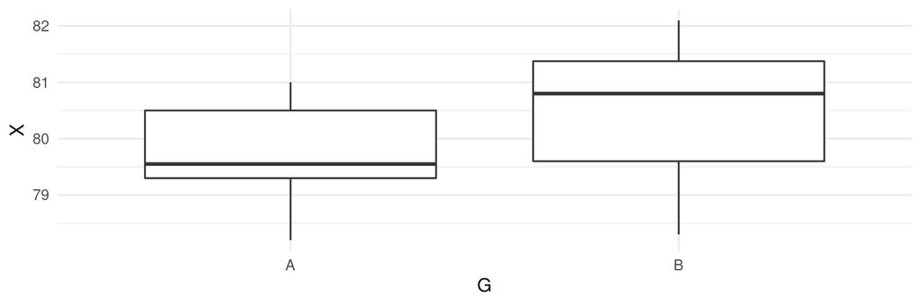

## Comparing group means (2)

- Step 3, 4, 5. Test statistics and p-values are easily calculated with R.

```r
t.test(X~G, data = data)
```

```
#>
#>  Welch Two Sample t-test
#>
#> data:  X by G
#> t = -1.638, df = 16.394, p-value = 0.1205
#> alternative hypothesis: true difference in means between group A and group B is not equal to 0
#> 95 percent confidence interval:
#>  -1.8562806  0.2362806
#> sample estimates:
#> mean in group A mean in group B
#>           79.70           80.51
```

## Independence tests

- \(H_0\) when comparing the means of two groups are we are deciding whether the expected value of a numerical variable is independent of a binary group variable.

Depending on the nature of the two variables, other tests exist to contrast their independence.

- Between categorical variables: Fisher exact test, or chi-squared contingency table test if Fisher does not work.

```r
fisher.test(table(X,Y)) # chisq.test(table(X,Y))
```

- Between numerical variable: test for Association/Correlation Between Paired Samples.

```r
cor.test(X,Y)
```

- Between categorical (\(X\)) and numerical (\(Y\)) variables: ANOVA test.

```r
summary(aov(Y~X))
```

## Categorical distribution

**Pearson’s chi-squared test**

- \(H_0\): \(X \sim Cat(\boldsymbol\pi = (\pi_1, \dots, \pi_k))\).
- Test statistic: \[ \chi^2 = \sum_{i=1}^k \frac{(O_i-E_i)^2}{E_i} \sim {\chi^2}_{k-1} \] where \(O_i\) is the number of times \(i\) was observed and \(E_i = n \times \pi_i\).

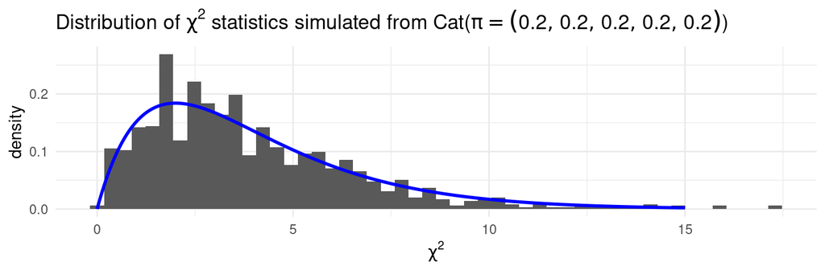

## Gaussian distribution

**Shapiro-Wilk test**

- \(H_0\): \(X \sim N(\mu,\sigma)\)
- Test statistic: \[ W = \frac{(\sum_{i=1}^n a_i x_{[i]})^2}{(\sum_{i=1}^n (x_i - \bar{x})^2)^2} \sim f_{W} \] where \(a_i\)’s are certain constants, \(x_{[i]}\) is the \(i\)-th smallest observation in \(X\) and \(f\) is a probability distribution for r.v. \(W\).

```r
set.seed(1)
x = rnorm(100)
shapiro.test(x)
```

```
#>
#>  Shapiro-Wilk normality test
#>
#> data:  x
#> W = 0.9956, p-value = 0.9876
```

## Homoscedasticity

For \(X\) categorical and \(Y\) numerical.

- \(H_0\): \(\text{Var}(Y | X)\) is constant.

```r
bartlett.test(Y~X)
```

- Bartlett’s test assumes normality. For non-normal variables better to use the Levene test (available in package `car`)

```r
car::leveneTest(Y~X)
```

## `broom` Statistical Objects into Tibbles

```r
binom.test(c(682, 243), p = 3/4)
```

```
#>
#>  Exact binomial test
#>
#> data:  c(682, 243)
#> number of successes = 682, number of trials = 925, p-value = 0.3825
#> alternative hypothesis: true probability of success is not equal to 0.75
#> 95 percent confidence interval:
#>  0.7076683 0.7654066
#> sample estimates:
#> probability of success
#>              0.7372973
```

With `broom`:

```r
library(broom)
tidy(binom.test(c(682, 243), p = 3/4))
```

```
#> # A tibble: 1 × 8
#>   estimate statistic p.value parameter conf.low conf.high method     alternative
#>      <dbl>     <dbl>   <dbl>     <dbl>    <dbl>     <dbl> <chr>      <chr>
#> 1    0.737       682   0.382       925    0.708     0.765 Exact bin… two.sided
```